# Classification and clustering (week 4)

> *This week introduced classification and clustering methods, such as LDA and k-means clustering*

In this exercise, Boston data from R package MASS was used. The data includes housing values in suburbs of Boston, such as crime rate, owner occupied houses, pupil-teacher ratios and so on. More information regarding the data is found [here](https://stat.ethz.ch/R-manual/R-devel/library/MASS/html/Boston.html).

The Boston dataset includes 506 observations from 14 variables. For example, crim means per capita crime rate by town, chas closeness to Charles river, nox the nitrogen oxides concentration, and age is proportion of owner-occupied units built prior to 1940. Variable rad includes index of accessibility to radial highways and lstat means lower status of the population (percent).

```r
#Loading in the data, observing the structure
data("Boston")
str(Boston)
```

```
## 'data.frame':    506 obs. of  14 variables:
##  $ crim   : num  0.00632 0.02731 0.02729 0.03237 0.06905 ...
##  $ zn     : num  18 0 0 0 0 0 12.5 12.5 12.5 12.5 ...
##  $ indus  : num  2.31 7.07 7.07 2.18 2.18 2.18 7.87 7.87 7.87 7.87 ...
##  $ chas   : int  0 0 0 0 0 0 0 0 0 0 ...
##  $ nox    : num  0.538 0.469 0.469 0.458 0.458 0.458 0.524 0.524 0.524 0.524 ...
##  $ rm     : num  6.58 6.42 7.18 7 7.15 ...
##  $ age    : num  65.2 78.9 61.1 45.8 54.2 58.7 66.6 96.1 100 85.9 ...
##  $ dis    : num  4.09 4.97 4.97 6.06 6.06 ...
##  $ rad    : int  1 2 2 3 3 3 5 5 5 5 ...
##  $ tax    : num  296 242 242 222 222 222 311 311 311 311 ...
##  $ ptratio: num  15.3 17.8 17.8 18.7 18.7 18.7 15.2 15.2 15.2 15.2 ...
##  $ black  : num  397 397 393 395 397 ...
##  $ lstat  : num  4.98 9.14 4.03 2.94 5.33 ...
##  $ medv   : num  24 21.6 34.7 33.4 36.2 28.7 22.9 27.1 16.5 18.9 ...
```

Looking at statistics of the data. Here, more of the owner-occupied units are build prior to 1940 and many are not close to Charles river.

```r
#Calculating descriptive statitics and visualising
summary(Boston)
```

```
##       crim                zn             indus            chas
##  Min.   : 0.00632   Min.   :  0.00   Min.   : 0.46   Min.   :0.00000
##  1st Qu.: 0.08205   1st Qu.:  0.00   1st Qu.: 5.19   1st Qu.:0.00000
##  Median : 0.25651   Median :  0.00   Median : 9.69   Median :0.00000
##  Mean   : 3.61352   Mean   : 11.36   Mean   :11.14   Mean   :0.06917
##  3rd Qu.: 3.67708   3rd Qu.: 12.50   3rd Qu.:18.10   3rd Qu.:0.00000
##  Max.   :88.97620   Max.   :100.00   Max.   :27.74   Max.   :1.00000
##       nox               rm             age              dis
##  Min.   :0.3850   Min.   :3.561   Min.   :  2.90   Min.   : 1.130
##  1st Qu.:0.4490   1st Qu.:5.886   1st Qu.: 45.02   1st Qu.: 2.100
##  Median :0.5380   Median :6.208   Median : 77.50   Median : 3.207
##  Mean   :0.5547   Mean   :6.285   Mean   : 68.57   Mean   : 3.795
##  3rd Qu.:0.6240   3rd Qu.:6.623   3rd Qu.: 94.08   3rd Qu.: 5.188
##  Max.   :0.8710   Max.   :8.780   Max.   :100.00   Max.   :12.127
##       rad              tax           ptratio          black
##  Min.   : 1.000   Min.   :187.0   Min.   :12.60   Min.   :  0.32
##  1st Qu.: 4.000   1st Qu.:279.0   1st Qu.:17.40   1st Qu.:375.38
##  Median : 5.000   Median :330.0   Median :19.05   Median :391.44
##  Mean   : 9.549   Mean   :408.2   Mean   :18.46   Mean   :356.67
##  3rd Qu.:24.000   3rd Qu.:666.0   3rd Qu.:20.20   3rd Qu.:396.23
##  Max.   :24.000   Max.   :711.0   Max.   :22.00   Max.   :396.90
##      lstat            medv
##  Min.   : 1.73   Min.   : 5.00
##  1st Qu.: 6.95   1st Qu.:17.02
##  Median :11.36   Median :21.20
##  Mean   :12.65   Mean   :22.53
##  3rd Qu.:16.95   3rd Qu.:25.00
##  Max.   :37.97   Max.   :50.00
```

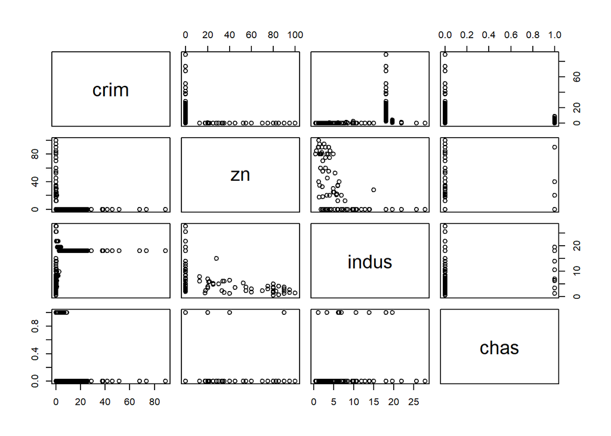

```r
pairs(Boston[1:4])
```

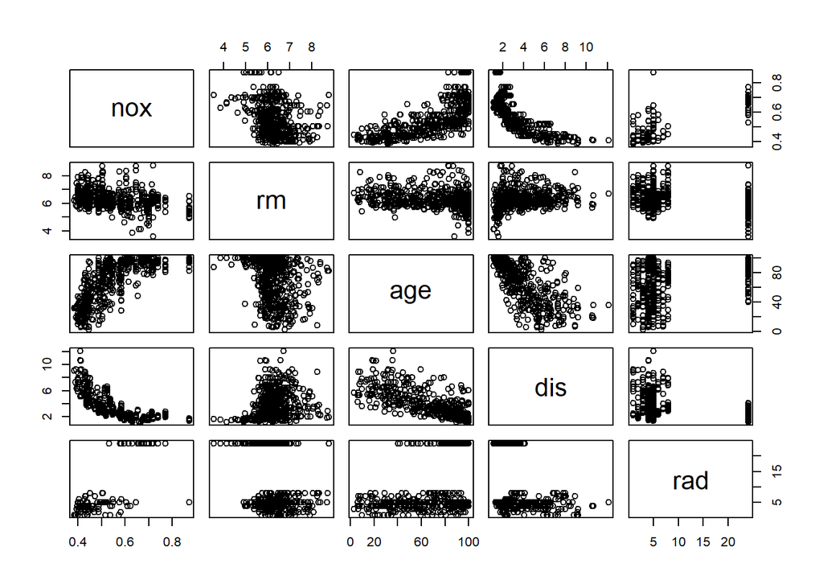

```r
pairs(Boston[5:9])
```

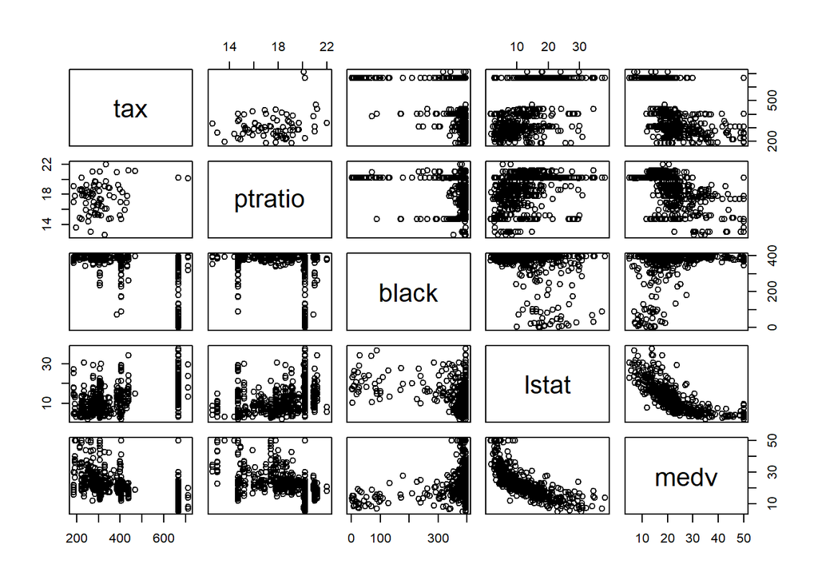

```r
pairs(Boston[10:14])
```

Zn and indus variables seem to have negative correlation (meaning where is residential land, there are no non-retailer business acres and vice versa). For example age and nox have positive vs age and dis have negative correlation.

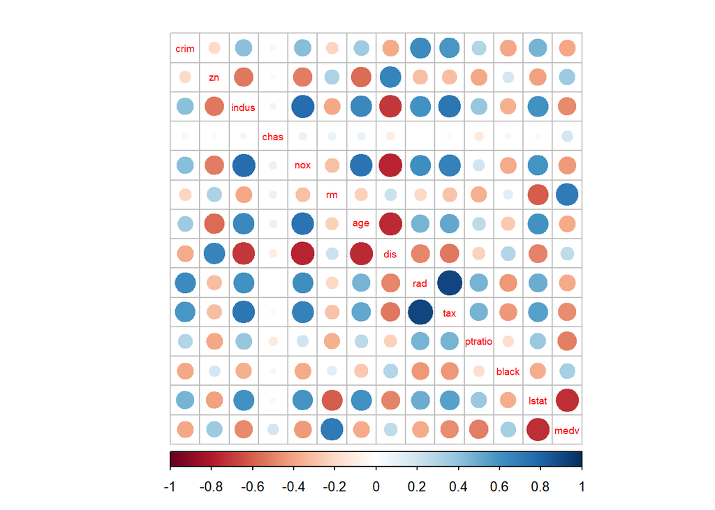

```r
cor_matrix<-cor(Boston) %>%
 round(digits = 2)
corrplot(cor_matrix, method="circle", cl.pos = "b", tl.pos = "d", tl.cex = 0.6)
```

Next, the data is standardized by decreasing the variable mean from each observation and dividing the number by sd. Therefore, each observation represents whether the real observation was bigger or smaller than the mean, and how far it was from the standard deviation.

```r
#Standardazing the data with z-scoring
boston_scaled <- scale(Boston)
summary(boston_scaled)
```

```
##       crim                 zn               indus              chas
##  Min.   :-0.419367   Min.   :-0.48724   Min.   :-1.5563   Min.   :-0.2723
##  1st Qu.:-0.410563   1st Qu.:-0.48724   1st Qu.:-0.8668   1st Qu.:-0.2723
##  Median :-0.390280   Median :-0.48724   Median :-0.2109   Median :-0.2723
##  Mean   : 0.000000   Mean   : 0.00000   Mean   : 0.0000   Mean   : 0.0000
##  3rd Qu.: 0.007389   3rd Qu.: 0.04872   3rd Qu.: 1.0150   3rd Qu.:-0.2723
##  Max.   : 9.924110   Max.   : 3.80047   Max.   : 2.4202   Max.   : 3.6648
##       nox                rm               age               dis
##  Min.   :-1.4644   Min.   :-3.8764   Min.   :-2.3331   Min.   :-1.2658
##  1st Qu.:-0.9121   1st Qu.:-0.5681   1st Qu.:-0.8366   1st Qu.:-0.8049
##  Median :-0.1441   Median :-0.1084   Median : 0.3171   Median :-0.2790
##  Mean   : 0.0000   Mean   : 0.0000   Mean   : 0.0000   Mean   : 0.0000
##  3rd Qu.: 0.5981   3rd Qu.: 0.4823   3rd Qu.: 0.9059   3rd Qu.: 0.6617
##  Max.   : 2.7296   Max.   : 3.5515   Max.   : 1.1164   Max.   : 3.9566
##       rad               tax             ptratio            black
##  Min.   :-0.9819   Min.   :-1.3127   Min.   :-2.7047   Min.   :-3.9033
##  1st Qu.:-0.6373   1st Qu.:-0.7668   1st Qu.:-0.4876   1st Qu.: 0.2049
##  Median :-0.5225   Median :-0.4642   Median : 0.2746   Median : 0.3808
##  Mean   : 0.0000   Mean   : 0.0000   Mean   : 0.0000   Mean   : 0.0000
##  3rd Qu.: 1.6596   3rd Qu.: 1.5294   3rd Qu.: 0.8058   3rd Qu.: 0.4332
##  Max.   : 1.6596   Max.   : 1.7964   Max.   : 1.6372   Max.   : 0.4406
##      lstat              medv
##  Min.   :-1.5296   Min.   :-1.9063
##  1st Qu.:-0.7986   1st Qu.:-0.5989
##  Median :-0.1811   Median :-0.1449
##  Mean   : 0.0000   Mean   : 0.0000
##  3rd Qu.: 0.6024   3rd Qu.: 0.2683
##  Max.   : 3.5453   Max.   : 2.9865
```

```r
boston_scaled <- as.data.frame(boston_scaled)
```

Calculating catecorical variable from crime, representing the crime rate

```r
bins <- quantile(boston_scaled$crim)
crime <- cut(boston_scaled$crim, breaks = bins, include.lowest = TRUE, label = c("low", "med_low", "med_high", "high"))
table(crime)
```

```
## crime
##      low  med_low med_high     high
##      127      126      126      127
```

```r
boston_scaled <- dplyr::select(boston_scaled, -crim)
boston_scaled <- data.frame(boston_scaled, crime)
```

Dividing data to test set and train set

```r
n <- nrow(boston_scaled)
ind <- sample(n,  size = n * 0.8)
train <- boston_scaled[ind,]
test <- boston_scaled[-ind,]
correct_classes <- test$crime
test <- dplyr::select(test, -crime)
```

Calculating linear discriminant analysis from the train data, by using crime rate as target variable.

```r
lda.fit <- lda(crime ~., data = train)
lda.fit
```

```
## Call:
## lda(crime ~ ., data = train)
##
## Prior probabilities of groups:
##       low   med_low  med_high      high
## 0.2425743 0.2376238 0.2698020 0.2500000
##
## Group means:
##                  zn      indus        chas        nox          rm        age
## low       1.0368670 -0.9328733 -0.11163110 -0.8815873  0.45941689 -0.9201229
## med_low  -0.1185415 -0.2623479  0.01475116 -0.5619994 -0.10232430 -0.3546586
## med_high -0.3991257  0.1905927  0.26947372  0.3908929  0.05970929  0.3753426
## high     -0.4872402  1.0171306 -0.11640431  1.0129151 -0.43858756  0.7747829
##                 dis        rad        tax     ptratio      black       lstat
## low       0.9226749 -0.6924106 -0.7303085 -0.49226997  0.3748478 -0.77682414
## med_low   0.3345447 -0.5356439 -0.4544478 -0.02180206  0.3107425 -0.14680951
## med_high -0.3466518 -0.3992086 -0.2834891 -0.22863538  0.0747121  0.03366768
## high     -0.8335012  1.6379981  1.5139626  0.78062517 -0.9007444  0.90699916
##                 medv
## low       0.54352177
## med_low   0.01965133
## med_high  0.13728305
## high     -0.75143481
##
## Coefficients of linear discriminants:
##                   LD1          LD2         LD3
## zn       0.1048401986  0.814530256 -0.86783228
## indus    0.0001572989 -0.255900819  0.40275491
## chas    -0.0824107177 -0.102530558  0.04936477
## nox      0.3110136041 -0.606449020 -1.48358944
## rm      -0.0714729126 -0.052143349 -0.06520491
## age      0.2776399687 -0.289493276 -0.24743865
## dis     -0.0828770634 -0.264434412  0.03356015
## rad      2.9622149866  0.916956852 -0.02766723
## tax      0.0351149452 -0.073366186  0.47668083
## ptratio  0.1074998275 -0.043816864 -0.27233274
## black   -0.1396461922 -0.001127432  0.09507244
## lstat    0.2174739762 -0.207801193  0.35745756
## medv     0.1426986687 -0.409899842 -0.24883748
##
## Proportion of trace:
##    LD1    LD2    LD3
## 0.9397 0.0461 0.0143
```

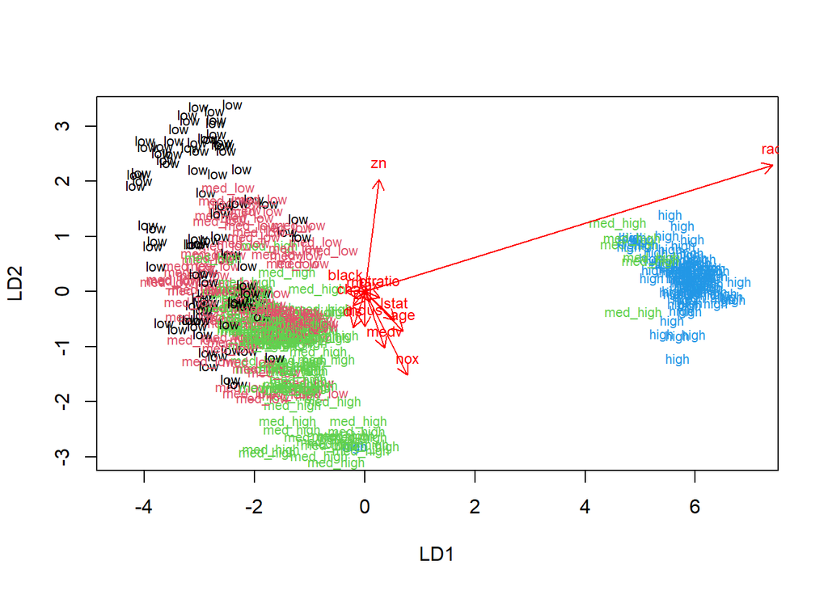

```
## integer(0)
```

```r
lda.arrows <- function(x, myscale = 1, arrow_heads = 0.1, color = "red", tex = 0.75, choices = c(1,2)){
  heads <- coef(x)
  arrows(x0 = 0, y0 = 0,
         x1 = myscale * heads[,choices[1]],
         y1 = myscale * heads[,choices[2]], col=color, length = arrow_heads)
  text(myscale * heads[,choices], labels = row.names(heads),
       cex = tex, col=color, pos=3)
}
classes <- as.numeric(train$crime)

plot(lda.fit, dimen = 2, col = classes, pch = classes)+
lda.arrows(lda.fit, myscale = 2.5)
```

The prediction capability of the algorithm is then tested using the test data.

```r
lda.pred <- predict(lda.fit, newdata = test)

table(correct = correct_classes, predicted = lda.pred$class)
```

```
##           predicted
## correct    low med_low med_high high
##   low       13      15        1    0
##   med_low    5      17        8    0
##   med_high   0       1       16    0
##   high       0       0        0   26
```